# Chapter 11: Generalized evidence synthesis

Bob

2025-03-02

```r
library('rjags')
library('coda')
library('jagshelper')
library('jagsUI')
library('mcmcplots')  # caterplot
library('dplyr')
library('knitr')      # kable
```

# Models discussed in the text

## `HRT_power_prior`

This is essentially the model from Box 11.1 (pp231-232), except the code in the text does ot compute `prob.OR1[k]`.

HRT - Power Prior Model

Adjusted for duration - centred at 5 years

Prior based on distribution of pooled effect (Lancet 1997)

OR 1.31 & 95%CI: 1.16 to 1.46 => logOR=0.27 & 95% CI: 0.144 to 0.382 => SD(logOR) = 0.061 => precision = 271.3

The original WinBUGS code gave an `Attempt to redefine node` errors in JAGS, which was addressed by moving the dataset copies to a data block. Here is a copy of the WinBUGS version:

```
model  {
  # Create multiple datasets
  for (i in 1:19){
    for(k in 1:12){
      rc[i,k] <- rc.dat[i]
      rt[i,k] <- rt.dat[i]
      nc[i,k] <- nc.dat[i]
      nt[i,k] <- nt.dat[i]
    }
  }

  # Estimate meta-analysis model for each value of alpha
  for (k in 1: 12) {
    for( i in 1 : 19 ) {
      rc[i,k] ~ dbin(pc[i,k], nc[i,k])
      rt[i,k] ~ dbin(pt[i,k], nt[i,k])
      logit(pc[i,k]) <- mu[i,k]
      logit(pt[i,k]) <- mu[i,k] + delta[i,k]+ beta*(duration[i]-5)
      mu[i,k] ~ dnorm(0.0,1.0E-6)
      delta[i,k] ~ dnorm(d[k], prec[k])
    }
    d[k] ~ dnorm(0.270, prec.d[k])  # Use mean of meta-analysis of obs data
    OR.5years[k]<- exp(d[k])
    prob.OR1[k] <- step(d[k])  # probability that OR>1, i.e. increase in risk of breast ca
    prec[k] <- 1/tau.sq[k]
    tau.sq[k] <- tau[k]*tau[k]
    tau[k] ~ dunif(0,5)
  }

  # Calculate precision  of prior (from Lancet meta-analysis of observational studies)
  # downweighted using alpha

  for (k in 1:12) {
    prec.d[k] <- alpha[k]*271.3
  }
  beta ~ dnorm(0.0,1.0E-6)
}
```

```r
# Model

model_code <- "

data {
  # Create multiple datasets
  for (i in 1:19){
    for(k in 1:12){
      rc[i,k] <- rc.dat[i]
      rt[i,k] <- rt.dat[i]
      nc[i,k] <- nc.dat[i]
      nt[i,k] <- nt.dat[i]
    }
  }
}

model  {

  # Estimate meta-analysis model for each value of alpha
  for (k in 1: 12) {
    for( i in 1 : 19 ) {
      rc[i,k] ~ dbin(pc[i,k], nc[i,k])
      rt[i,k] ~ dbin(pt[i,k], nt[i,k])
      logit(pc[i,k]) <- mu[i,k]
      logit(pt[i,k]) <- mu[i,k] + delta[i,k]+ beta*(duration[i]-5)
      mu[i,k] ~ dnorm(0.0,1.0E-6)
      delta[i,k] ~ dnorm(d[k], prec[k])
    }
    d[k] ~ dnorm(0.270, prec.d[k])  # Use mean of meta-analysis of obs data
    OR.5years[k]<- exp(d[k])
    prob.OR1[k] <- step(d[k])  # probability that OR>1, i.e. increase in risk of breast ca
    prec[k] <- 1/tau.sq[k]
    tau.sq[k] <- tau[k]*tau[k]
    tau[k] ~ dunif(0,5)
  }

  # Calculate precision  of prior (from Lancet meta-analysis of observational studies)
  # downweighted using alpha

  for (k in 1:12) {
    prec.d[k] <- alpha[k]*271.3
  }
  beta ~ dnorm(0.0,1.0E-6)
}
" %>% textConnection


# Data

data <- list(
  rt.dat = c(0,2,1,0,1,0,0,2,7,6,1,32,2,1,0,1,0,2,5),
  nt.dat = c(84,56,116,62,39,31,30,100,701,1128,37,1380,232,150,215,204,243,502,337),
  rc.dat = c(4,1,1,1,1,1,1,0,1,0,0,25,1,1,1,0,4,5,5),
  nc.dat = c(84,259,40,20,36,70,30,51,174,137,37,1383,232,50,106,105,246,504,327),
  duration=c(10,2,1,2,1,2.92,1,2,3,2,2,4.08,5,2,1,3.17,3,4.58,2.83),
  alpha=c(0.000001,0.001,0.1,0.2,0.3,0.4,0.5,0.6,0.7,0.8,0.9,1.0)
)

# Starting/initial values: same as random effects model without sd
initial_values <- list(
  list(
    mu=structure(
      .Data=rep(-5, 19 * 12),
      .Dim=c(19,12)
    ),
    delta=structure(
      .Data=rep(-0.54, 19 * 12),
      .Dim=c(19,12)
    ),
    d = rep(-0.51, 12),
    beta=-0.19,
    tau=rep(1, 12)
  )
)

parameters_to_save <- c("OR.5years", "prob.OR1")


results <- jags(data = data,
            inits = initial_values,
            parameters.to.save = parameters_to_save,
            model.file = model_code,
            n.chains = length(initial_values),
            n.adapt = 100,
            n.iter = 50000,
            n.burnin = 20000,
            n.thin = 2)
```

```
##
## Processing function input.......
##
## Done.
##
## Compiling data graph
##    Initializing
##    Reading data back into data table
##
##
## Adaptive phase, 100 iterations x 1 chains
## If no progress bar appears JAGS has decided not to adapt
##
##
##  Burn-in phase, 20000 iterations x 1 chains
##
##
## Sampling from joint posterior, 30000 iterations x 1 chains
##
##
## Calculating statistics.......
##
## Done.
```

```r
hrt_pp_results_summary <- summary(results)

hrt_pp_results_summary %>% kable
```

|  | mean | sd | 2.5% | 25% | 50% | 75% | 97.5% | Rhat | n.eff | overlap0 | f |
| --- | --- | --- | --- | --- | --- | --- | --- | --- | --- | --- | --- |
| OR.5years[1] | 0.8949853 | 0.7656178 | 0.2092124 | 0.5503685 | 0.7672482 | 1.031918 | 2.550306 | NA | 1 | 0 | 1 |
| OR.5years[2] | 0.8796523 | 0.5349580 | 0.2655798 | 0.5919664 | 0.7956919 | 1.029669 | 2.053577 | NA | 1 | 0 | 1 |
| OR.5years[3] | 1.1814185 | 0.2143821 | 0.8234532 | 1.0268898 | 1.1606723 | 1.308315 | 1.662217 | NA | 1 | 0 | 1 |
| OR.5years[4] | 1.2135222 | 0.1615257 | 0.9418547 | 1.0982385 | 1.1984792 | 1.311959 | 1.569625 | NA | 1 | 0 | 1 |
| OR.5years[5] | 1.2617467 | 0.1340840 | 1.0242005 | 1.1676769 | 1.2537995 | 1.346394 | 1.547377 | NA | 1 | 0 | 1 |
| OR.5years[6] | 1.2675923 | 0.1182771 | 1.0507914 | 1.1857738 | 1.2657751 | 1.341252 | 1.514531 | NA | 1 | 0 | 1 |
| OR.5years[7] | 1.2739905 | 0.1096061 | 1.0729082 | 1.1970653 | 1.2708239 | 1.344671 | 1.505185 | NA | 1 | 0 | 1 |
| OR.5years[8] | 1.2786246 | 0.0981472 | 1.1004973 | 1.2122358 | 1.2740686 | 1.341705 | 1.483150 | NA | 1 | 0 | 1 |
| OR.5years[9] | 1.2849800 | 0.0900721 | 1.1184932 | 1.2228520 | 1.2815390 | 1.344460 | 1.473229 | NA | 1 | 0 | 1 |
| OR.5years[10] | 1.2847787 | 0.0856488 | 1.1267172 | 1.2252652 | 1.2811588 | 1.340982 | 1.459292 | NA | 1 | 0 | 1 |
| OR.5years[11] | 1.2889349 | 0.0845483 | 1.1212238 | 1.2324253 | 1.2868289 | 1.344188 | 1.460809 | NA | 1 | 0 | 1 |
| OR.5years[12] | 1.2899069 | 0.0776956 | 1.1458869 | 1.2362107 | 1.2865166 | 1.341088 | 1.450225 | NA | 1 | 0 | 1 |
| prob.OR1[1] | 0.2729333 | 0.4454817 | 0.0000000 | 0.0000000 | 0.0000000 | 1.000000 | 1.000000 | NA | 1 | 1 | 1 |
| prob.OR1[2] | 0.2762667 | 0.4471652 | 0.0000000 | 0.0000000 | 0.0000000 | 1.000000 | 1.000000 | NA | 1 | 1 | 1 |
| prob.OR1[3] | 0.8004000 | 0.3997130 | 0.0000000 | 1.0000000 | 1.0000000 | 1.000000 | 1.000000 | NA | 1 | 1 | 1 |
| prob.OR1[4] | 0.9263333 | 0.2612364 | 0.0000000 | 1.0000000 | 1.0000000 | 1.000000 | 1.000000 | NA | 1 | 1 | 1 |
| prob.OR1[5] | 0.9854000 | 0.1199492 | 1.0000000 | 1.0000000 | 1.0000000 | 1.000000 | 1.000000 | NA | 1 | 0 | 1 |
| prob.OR1[6] | 0.9943333 | 0.0750662 | 1.0000000 | 1.0000000 | 1.0000000 | 1.000000 | 1.000000 | NA | 1 | 0 | 1 |
| prob.OR1[7] | 0.9976000 | 0.0489326 | 1.0000000 | 1.0000000 | 1.0000000 | 1.000000 | 1.000000 | NA | 1 | 0 | 1 |
| prob.OR1[8] | 0.9994000 | 0.0244884 | 1.0000000 | 1.0000000 | 1.0000000 | 1.000000 | 1.000000 | NA | 1 | 0 | 1 |
| prob.OR1[9] | 0.9998000 | 0.0141412 | 1.0000000 | 1.0000000 | 1.0000000 | 1.000000 | 1.000000 | NA | 1 | 0 | 1 |
| prob.OR1[10] | 1.0000000 | 0.0000000 | 1.0000000 | 1.0000000 | 1.0000000 | 1.000000 | 1.000000 | NA | 1 | 0 | 1 |
| prob.OR1[11] | 0.9999333 | 0.0081650 | 1.0000000 | 1.0000000 | 1.0000000 | 1.000000 | 1.000000 | NA | 1 | 0 | 1 |
| prob.OR1[12] | 1.0000000 | 0.0000000 | 1.0000000 | 1.0000000 | 1.0000000 | 1.000000 | 1.000000 | NA | 1 | 0 | 1 |
| deviance | 1444.2770618 | 32.6674243 | 1381.8415438 | 1420.3225419 | 1444.3406160 | 1468.221537 | 1505.565290 | NA | 1 | 0 | 1 |

### WinBUGS results for HRT power prior model

```r
hrt_ppwb_results <- "
node     mean    sd  MC error   2.5%    median  97.5%   start   sample
OR.5years[1]    0.8338  0.4129  0.01195 0.2669  0.7939  1.692   20001   10000
OR.5years[2]    0.8239  0.3979  0.01004 0.2994  0.7648  1.695   20001   10000
OR.5years[3]    1.181   0.207   0.006385    0.8387  1.162   1.656   20001   10000
OR.5years[4]    1.235   0.1614  0.00419 0.947   1.225   1.579   20001   10000
OR.5years[5]    1.257   0.1352  0.002739    1.016   1.247   1.548   20001   10000
OR.5years[6]    1.27    0.1193  0.002548    1.06    1.263   1.529   20001   10000
OR.5years[7]    1.276   0.105   0.002092    1.085   1.271   1.502   20001   10000
OR.5years[8]    1.279   0.09981 0.002264    1.096   1.274   1.488   20001   10000
OR.5years[9]    1.285   0.09417 0.002484    1.115   1.282   1.477   20001   10000
OR.5years[10]   1.29    0.08679 0.001553    1.128   1.287   1.466   20001   10000
OR.5years[11]   1.29    0.0809  0.001679    1.14    1.287   1.458   20001   10000
OR.5years[12]   1.29    0.07937 0.002053    1.139   1.289   1.449   20001   10000
prob.OR1[1] 0.2537  0.4351  0.01604 0.0 0.0 1.0 20001   10000
prob.OR1[2] 0.2292  0.4203  0.01169 0.0 0.0 1.0 20001   10000
prob.OR1[3] 0.8087  0.3933  0.009994    0.0 1.0 1.0 20001   10000
prob.OR1[4] 0.9383  0.2406  0.006712    0.0 1.0 1.0 20001   10000
prob.OR1[5] 0.9826  0.1308  0.001813    1.0 1.0 1.0 20001   10000
prob.OR1[6] 0.9942  0.07594 7.808E-4    1.0 1.0 1.0 20001   10000
prob.OR1[7] 0.9988  0.03462 3.562E-4    1.0 1.0 1.0 20001   10000
prob.OR1[8] 0.9992  0.02827 2.727E-4    1.0 1.0 1.0 20001   10000
prob.OR1[9] 0.9999  0.009999    1.0E-4  1.0 1.0 1.0 20001   10000
prob.OR1[10]    0.9999  0.009999    1.0E-4  1.0 1.0 1.0 20001   10000
prob.OR1[11]    1.0 0.0 1.0E-12 1.0 1.0 1.0 20001   10000
prob.OR1[12]    1.0 0.0 1.0E-12 1.0 1.0 1.0 20001   10000
" %>% read.table(text=., sep="\t", header=TRUE, check.names=FALSE)

# rename = c(X2.5.="2.5%", `X97.5.`= "97.5%")
# for (old_name in names(rename)){
#   new_name <- rename[old_name]
#   names(ppwb_results)[names(ppwb_results)==old_name] <- new_name
# }
hrt_ppwb_results %>% kable
```

| node | mean | sd | MC error | 2.5% | median | 97.5% | start | sample |
| --- | --- | --- | --- | --- | --- | --- | --- | --- |
| OR.5years[1] | 0.8338 | 0.412900 | 0.0119500 | 0.2669 | 0.7939 | 1.692 | 20001 | 10000 |
| OR.5years[2] | 0.8239 | 0.397900 | 0.0100400 | 0.2994 | 0.7648 | 1.695 | 20001 | 10000 |
| OR.5years[3] | 1.1810 | 0.207000 | 0.0063850 | 0.8387 | 1.1620 | 1.656 | 20001 | 10000 |
| OR.5years[4] | 1.2350 | 0.161400 | 0.0041900 | 0.9470 | 1.2250 | 1.579 | 20001 | 10000 |
| OR.5years[5] | 1.2570 | 0.135200 | 0.0027390 | 1.0160 | 1.2470 | 1.548 | 20001 | 10000 |
| OR.5years[6] | 1.2700 | 0.119300 | 0.0025480 | 1.0600 | 1.2630 | 1.529 | 20001 | 10000 |
| OR.5years[7] | 1.2760 | 0.105000 | 0.0020920 | 1.0850 | 1.2710 | 1.502 | 20001 | 10000 |
| OR.5years[8] | 1.2790 | 0.099810 | 0.0022640 | 1.0960 | 1.2740 | 1.488 | 20001 | 10000 |
| OR.5years[9] | 1.2850 | 0.094170 | 0.0024840 | 1.1150 | 1.2820 | 1.477 | 20001 | 10000 |
| OR.5years[10] | 1.2900 | 0.086790 | 0.0015530 | 1.1280 | 1.2870 | 1.466 | 20001 | 10000 |
| OR.5years[11] | 1.2900 | 0.080900 | 0.0016790 | 1.1400 | 1.2870 | 1.458 | 20001 | 10000 |
| OR.5years[12] | 1.2900 | 0.079370 | 0.0020530 | 1.1390 | 1.2890 | 1.449 | 20001 | 10000 |
| prob.OR1[1] | 0.2537 | 0.435100 | 0.0160400 | 0.0000 | 0.0000 | 1.000 | 20001 | 10000 |
| prob.OR1[2] | 0.2292 | 0.420300 | 0.0116900 | 0.0000 | 0.0000 | 1.000 | 20001 | 10000 |
| prob.OR1[3] | 0.8087 | 0.393300 | 0.0099940 | 0.0000 | 1.0000 | 1.000 | 20001 | 10000 |
| prob.OR1[4] | 0.9383 | 0.240600 | 0.0067120 | 0.0000 | 1.0000 | 1.000 | 20001 | 10000 |
| prob.OR1[5] | 0.9826 | 0.130800 | 0.0018130 | 1.0000 | 1.0000 | 1.000 | 20001 | 10000 |
| prob.OR1[6] | 0.9942 | 0.075940 | 0.0007808 | 1.0000 | 1.0000 | 1.000 | 20001 | 10000 |
| prob.OR1[7] | 0.9988 | 0.034620 | 0.0003562 | 1.0000 | 1.0000 | 1.000 | 20001 | 10000 |
| prob.OR1[8] | 0.9992 | 0.028270 | 0.0002727 | 1.0000 | 1.0000 | 1.000 | 20001 | 10000 |
| prob.OR1[9] | 0.9999 | 0.009999 | 0.0001000 | 1.0000 | 1.0000 | 1.000 | 20001 | 10000 |
| prob.OR1[10] | 0.9999 | 0.009999 | 0.0001000 | 1.0000 | 1.0000 | 1.000 | 20001 | 10000 |
| prob.OR1[11] | 1.0000 | 0.000000 | 0.0000000 | 1.0000 | 1.0000 | 1.000 | 20001 | 10000 |
| prob.OR1[12] | 1.0000 | 0.000000 | 0.0000000 | 1.0000 | 1.0000 | 1.000 | 20001 | 10000 |

## `HRT_bias_allowance`

This is the code from Box 11.2 (pp243-235), with some of the lines in a different order. The code in the text also does not compute `prob.OR1`.

HRT Bias Allowance Model

Adjusted for duration - centred at 5 years

Summary of observational evidence (Lancet 1997)

OR 1.31 & 95%CI: 1.16 to 1.46 => logOR=0.27 & 95% CI: 0.144 to 0.382 => SD(logOR) = 0.061 => var = 0.0037 + var.bias

Var.bias derived from 19 meta-analyses of empirical estimates of studies comparing RCTs and non-randomised studies

```r
# Model

model_code <- "model {
  for(j in 1 : Nstud) {
    rc[j] ~ dbin(pc[j], nc[j])
    rt[j] ~ dbin(pt[j], nt[j])
    logit(pc[j]) <- mu[j]
    logit(pt[j]) <- mu[j] + delta[j] + beta*(duration[j]-5)
    mu[j] ~ dnorm(0.0,1.0E-5)
    delta[j] ~ dnorm(d, prec)
  }

  # Meta-meta-analysis of 19 meta-analyses comparing RCTs and
  # NRCTs (Ioannidis et al 2001)

  for( j in 1 : Nma) {
    logRRR [j] ~ dnorm(d.bias, prec.bias)
  }

  # Priors

  prec.bias <- 1/tau.sq.bias
  tau.sq.bias <- tau.bias*tau.bias

  d ~ dnorm(0.27, prec.d)
  prec.d <- 1/tau.sq.d
  tau.sq.d <- 0.0037 + tau.sq.bias

  prec <- 1/tau.sq
  tau.sq <- tau*tau

  tau ~ dunif(0,5)
  tau.bias ~ dunif(0,5)
  d.bias ~ dnorm(0.0,1.0E-5)
  beta ~ dnorm(0.0,1.0E-5)
  OR<- exp(d)
  prob.OR1 <- step(d)
}

" %>% textConnection


# Data

data <- list(
  rt = c(0,2,1,0,1,0,0,2,7,6,1,32,2,1,0,1,0,2,5),
  nt = c(84,56,116,62,39,31,30,100,701,1128,37,1380,232,150,215,204,243,502,337),
  rc = c(4,1,1,1,1,1,1,0,1,0,0,25,1,1,1,0,4,5,5),
  nc = c(84,259,40,20,36,70,30,51,174,137,37,1383,232,50,106,105,246,504,327),
  duration=c(10,2,1,2,1,2.92,1,2,3,2,2,4.08,5,2,1,3.17,3,4.58,2.83),
  Nstud = 19,
  Nma=19,
  logRRR = c(-1.406497068, -0.182721637, 0.299363577, 0.087094707,
    0.805135683, 0.017839918, -0.167235919, 0.133656385, -0.038740828, 0.969262617, 0.083421608,
    -0.432322562, 0, 0.347129531, 0.038258712, -0.066139803, 0.206200831, 0.1889661, -0.534435489)
)

# Starting/initial values: same as random effects model without sd
initial_values <- list(
  list(d = 0,
       tau=1,
       mu = c(0, 0, 0, 0, 0, 0, 0, 0, 0, 0, 0, 0, 0, 0, 0, 0, 0, 0, 0),
         delta = c(0, 0, 0, 0, 0, 0, 0, 0, 0, 0, 0, 0, 0, 0, 0, 0, 0, 0, 0),
         d.bias=0,
         tau.bias=1,
         beta=0
  )
)

parameters_to_save <- c("OR", "beta", "d", "prob.OR1", "tau", "tau.bias")


results <- jags(data = data,
            inits = initial_values,
            parameters.to.save = parameters_to_save,
            model.file = model_code,
            n.chains = length(initial_values),
            n.adapt = 100,
            n.iter = 50000,
            n.burnin = 20000,
            n.thin = 2)
```

```
##
## Processing function input.......
##
## Done.
##
##
##
## Adaptive phase, 100 iterations x 1 chains
## If no progress bar appears JAGS has decided not to adapt
##
##
##  Burn-in phase, 20000 iterations x 1 chains
##
##
## Sampling from joint posterior, 30000 iterations x 1 chains
##
##
## Calculating statistics.......
##
## Done.
```

```r
hrt_ba_results_summary <- summary(results)

hrt_ba_results_summary %>% kable
```

|  | mean | sd | 2.5% | 25% | 50% | 75% | 97.5% | Rhat | n.eff | overlap0 | f |
| --- | --- | --- | --- | --- | --- | --- | --- | --- | --- | --- | --- |
| OR | 0.9158757 | 0.3931241 | 0.3761601 | 0.6566275 | 0.8450022 | 1.0925418 | 1.8592248 | NA | 1 | 0 | 1.0000000 |
| beta | -0.1053754 | 0.2219056 | -0.5470834 | -0.2408173 | -0.1101510 | 0.0224646 | 0.3622339 | NA | 1 | 1 | 0.7135333 |
| d | -0.1681087 | 0.3987967 | -0.9777405 | -0.4206384 | -0.1684161 | 0.0885069 | 0.6201596 | NA | 1 | 1 | 0.6756000 |
| prob.OR1 | 0.3244000 | 0.4681658 | 0.0000000 | 0.0000000 | 0.0000000 | 1.0000000 | 1.0000000 | NA | 1 | 1 | 1.0000000 |
| tau | 1.2886809 | 0.8503507 | 0.1375596 | 0.6806153 | 1.0933985 | 1.7034002 | 3.4806481 | NA | 1 | 0 | 1.0000000 |
| tau.bias | 0.5383703 | 0.0989466 | 0.3825327 | 0.4684217 | 0.5242217 | 0.5931000 | 0.7718074 | NA | 1 | 0 | 1.0000000 |
| deviance | 147.2603882 | 9.5983198 | 128.9372335 | 140.6467787 | 147.2200887 | 153.5941550 | 166.6942720 | NA | 1 | 0 | 1.0000000 |

```r
hrt_bawb_results <- "
node     mean    sd  MC error   2.5%    median  97.5%   start   sample
OR  0.8954  0.3737  0.01416 0.3843  0.8282  1.845   10001   10000
beta    -0.1301 0.1952  0.008616    -0.5204 -0.1325 0.2612  10001   10000
d   -0.1862 0.3861  0.01477 -0.9563 -0.1885 0.6126  10001   10000
prob.OR1    0.294   0.4556  0.01666 0.0 0.0 1.0 10001   10000
tau 1.082   0.778   0.05142 0.03262 0.9523  2.985   10001   10000
tau.bias    0.5373  0.09916 0.001401    0.3867  0.5227  0.7721  10001   10000
" %>% read.table(text=., sep="\t", header=TRUE, check.names=FALSE)

hrt_bawb_results %>% kable
```

| node | mean | sd | MC error | 2.5% | median | 97.5% | start | sample |
| --- | --- | --- | --- | --- | --- | --- | --- | --- |
| OR | 0.8954 | 0.37370 | 0.014160 | 0.38430 | 0.8282 | 1.8450 | 10001 | 10000 |
| beta | -0.1301 | 0.19520 | 0.008616 | -0.52040 | -0.1325 | 0.2612 | 10001 | 10000 |
| d | -0.1862 | 0.38610 | 0.014770 | -0.95630 | -0.1885 | 0.6126 | 10001 | 10000 |
| prob.OR1 | 0.2940 | 0.45560 | 0.016660 | 0.00000 | 0.0000 | 1.0000 | 10001 | 10000 |
| tau | 1.0820 | 0.77800 | 0.051420 | 0.03262 | 0.9523 | 2.9850 | 10001 | 10000 |
| tau.bias | 0.5373 | 0.09916 | 0.001401 | 0.38670 | 0.5227 | 0.7721 | 10001 | 10000 |

## Hierarchical model

This is the code from Box 11.3 (p. 242). It was not included in the supplementary materials, so I typed it in by hand. I changed the name of a variable originally called ‘mean’ to ‘my_mean’, in case that is a reserved word in JAGS. This code runs, but I do not have official results to compare it to. The data values have not been double-checked. I added a second chain with arbitrary initial values, just to see that they both give similar distributions.

```r
model_code <- "
model {
  # Randomized controlled trials
  for (i in 1:R){
    rct.prec[i] <- 1/(rct.serd[i] * rct.serd[i])
    rct.rd[i] ~ dnorm(rct.psi[i], rct.prec[i])
    rct.psi[i] <- theta[1] + (rct.z[i] * sd.theta[1])
    rct.z[i] ~ dnorm(0, 1)
  }

  # Comparative cohort studies model
  for (i in 1:C){
    coh.prec[i] <- 1/(coh.serd[i] * coh.serd[i])
    coh.rd[i] ~ dnorm(coh.psi[i], coh.prec[i])
    coh.psi[i] <- theta[2] + (coh.z[i] * sd.theta[2])
    coh.z[i] ~ dnorm(0, 1)
  }

  # Before after studies model
  for (i in 1:B){
    ba.prec[i] <- 1/(ba.serd[1] * ba.serd[1])
    ba.rd[i] ~ dnorm(ba.psi[i], ba.prec[i])
    ba.psi[i] <- theta[3] + (ba.z[1] * sd.theta[3])
    ba.z[i] ~ dnorm(0, 1)
  }

  # Combining all 3 sources
  for (i in 1:T){
    theta[i] <- my_mean + (u[i] * sd.mean)  # !!! in case 'mean' is a reserved word
    u[i] ~ dnorm(0, 1)
    sd.theta[i]  ~ dnorm(0, 0.1)I(0,)
    var.theta[i] <- sd.theta[i] * sd.theta[i]   # !!! not used?
    prec.theta[i] <- 1/(sd.theta[i] * sd.theta[i])
  }

  my_mean ~ dnorm(0, 0.01)
  sd.mean ~ dnorm(0, 0.1)I(0,)
  var.mean <- sd.mean * sd.mean # !!! not used ?
  prec.mean <- 1/(sd.mean * sd.mean)

}" %>% textConnection

data <- list(
  R=9, C=7, B=10, T=3,
  rct.rd=c( -10.51552, -2.028398, 4.115085, 6.479482, 0.0078509, 0.0, 2.247191,
            -5.817028, -3.984064),
  rct.serd=c(4.762193, 2.871006, 7.142432, 5.032322, 0.8079891, 8.058098,
             3.1075, 44.53912, 5.587013),
  ba.rd=c(-4.036327, 2.304048, -0.6941801, -3.186446,-7.431126, -1.458522,
          -4.036984, -1.613824, -1.461775, -0.1177738),
  ba.serd=c(2.242277, 3.579612, 0.6056279, 0.9381518, 2.121014, 0.5100973,
            1.072718, 0.6358061, 0.507642, 0.1981163),
  coh.rd=c(-1.41, -2.19, -4.34, -2.84, -2.53, -0.23, -0.46),
  coh.serd=c(1.433, 4.71, 1.914, 1.052, 3.081, 0.232, 0.123)
)

initial_values <- list(
  list( my_mean=-0.001, sd.mean=0.001, sd.theta=rep(0.001, 3)),
  list( my_mean= 0.1, sd.mean=0.1, sd.theta=rep(0.01, 3))
)

parameters_to_save <- c("rct.rd", "coh.rd", "ba.rd", "my_mean")


results <- jags(data = data,
            inits = initial_values,
            parameters.to.save = parameters_to_save,
            model.file = model_code,
            n.chains = length(initial_values),
            n.adapt = 100,
            n.iter = 50000,
            n.burnin = 20000)
```

```
##
## Processing function input.......
##
## Done.
##
##
##
## Adaptive phase, 100 iterations x 2 chains
## If no progress bar appears JAGS has decided not to adapt
##
##
##  Burn-in phase, 20000 iterations x 2 chains
##
##
## Sampling from joint posterior, 30000 iterations x 2 chains
##
##
## Calculating statistics.......
##
## Done.
```

```r
summary(results)
```

```
##                  mean       sd        2.5%         25%         50%         75%
## rct.rd[1] -10.5155200 0.000000 -10.5155200 -10.5155200 -10.5155200 -10.5155200
## rct.rd[2]  -2.0283980 0.000000  -2.0283980  -2.0283980  -2.0283980  -2.0283980
## rct.rd[3]   4.1150850 0.000000   4.1150850   4.1150850   4.1150850   4.1150850
## rct.rd[4]   6.4794820 0.000000   6.4794820   6.4794820   6.4794820   6.4794820
## rct.rd[5]   0.0078509 0.000000   0.0078509   0.0078509   0.0078509   0.0078509
## rct.rd[6]   0.0000000 0.000000   0.0000000   0.0000000   0.0000000   0.0000000
## rct.rd[7]   2.2471910 0.000000   2.2471910   2.2471910   2.2471910   2.2471910
## rct.rd[8]  -5.8170280 0.000000  -5.8170280  -5.8170280  -5.8170280  -5.8170280
## rct.rd[9]  -3.9840640 0.000000  -3.9840640  -3.9840640  -3.9840640  -3.9840640
## coh.rd[1]  -1.4100000 0.000000  -1.4100000  -1.4100000  -1.4100000  -1.4100000
## coh.rd[2]  -2.1900000 0.000000  -2.1900000  -2.1900000  -2.1900000  -2.1900000
## coh.rd[3]  -4.3400000 0.000000  -4.3400000  -4.3400000  -4.3400000  -4.3400000
## coh.rd[4]  -2.8400000 0.000000  -2.8400000  -2.8400000  -2.8400000  -2.8400000
## coh.rd[5]  -2.5300000 0.000000  -2.5300000  -2.5300000  -2.5300000  -2.5300000
## coh.rd[6]  -0.2300000 0.000000  -0.2300000  -0.2300000  -0.2300000  -0.2300000
## coh.rd[7]  -0.4600000 0.000000  -0.4600000  -0.4600000  -0.4600000  -0.4600000
## ba.rd[1]   -4.0363270 0.000000  -4.0363270  -4.0363270  -4.0363270  -4.0363270
## ba.rd[2]    2.3040480 0.000000   2.3040480   2.3040480   2.3040480   2.3040480
## ba.rd[3]   -0.6941801 0.000000  -0.6941801  -0.6941801  -0.6941801  -0.6941801
## ba.rd[4]   -3.1864460 0.000000  -3.1864460  -3.1864460  -3.1864460  -3.1864460
## ba.rd[5]   -7.4311260 0.000000  -7.4311260  -7.4311260  -7.4311260  -7.4311260
## ba.rd[6]   -1.4585220 0.000000  -1.4585220  -1.4585220  -1.4585220  -1.4585220
## ba.rd[7]   -4.0369840 0.000000  -4.0369840  -4.0369840  -4.0369840  -4.0369840
## ba.rd[8]   -1.6138240 0.000000  -1.6138240  -1.6138240  -1.6138240  -1.6138240
## ba.rd[9]   -1.4617750 0.000000  -1.4617750  -1.4617750  -1.4617750  -1.4617750
## ba.rd[10]  -0.1177738 0.000000  -0.1177738  -0.1177738  -0.1177738  -0.1177738
## my_mean    -1.0957379 1.226708  -3.6086669  -1.7223720  -1.0691212  -0.4650175
## deviance  122.5501061 4.579193 114.5748887 119.2752496 122.1611227 125.5665307
##                 97.5%     Rhat n.eff overlap0      f
## rct.rd[1] -10.5155200       NA     1        0 1.0000
## rct.rd[2]  -2.0283980       NA     1        0 1.0000
## rct.rd[3]   4.1150850       NA     1        0 1.0000
## rct.rd[4]   6.4794820       NA     1        0 1.0000
## rct.rd[5]   0.0078509       NA     1        0 1.0000
## rct.rd[6]   0.0000000       NA     1        1 1.0000
## rct.rd[7]   2.2471910       NA     1        0 1.0000
## rct.rd[8]  -5.8170280       NA     1        0 1.0000
## rct.rd[9]  -3.9840640       NA     1        0 1.0000
## coh.rd[1]  -1.4100000       NA     1        0 1.0000
## coh.rd[2]  -2.1900000       NA     1        0 1.0000
## coh.rd[3]  -4.3400000       NA     1        0 1.0000
## coh.rd[4]  -2.8400000       NA     1        0 1.0000
## coh.rd[5]  -2.5300000       NA     1        0 1.0000
## coh.rd[6]  -0.2300000       NA     1        0 1.0000
## coh.rd[7]  -0.4600000       NA     1        0 1.0000
## ba.rd[1]   -4.0363270       NA     1        0 1.0000
## ba.rd[2]    2.3040480       NA     1        0 1.0000
## ba.rd[3]   -0.6941801       NA     1        0 1.0000
## ba.rd[4]   -3.1864460       NA     1        0 1.0000
## ba.rd[5]   -7.4311260       NA     1        0 1.0000
## ba.rd[6]   -1.4585220       NA     1        0 1.0000
## ba.rd[7]   -4.0369840       NA     1        0 1.0000
## ba.rd[8]   -1.6138240       NA     1        0 1.0000
## ba.rd[9]   -1.4617750       NA     1        0 1.0000
## ba.rd[10]  -0.1177738       NA     1        0 1.0000
## my_mean     1.4368996 1.000015 60000        1 0.8709
## deviance  132.2592140 1.000111 38234        0 1.0000
```

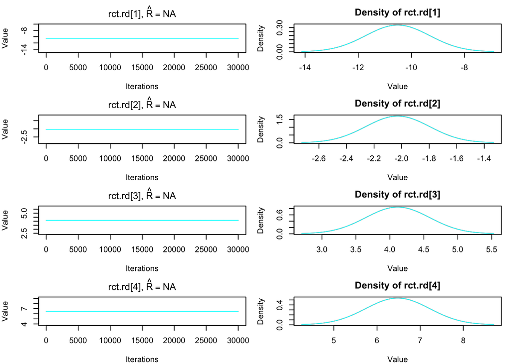

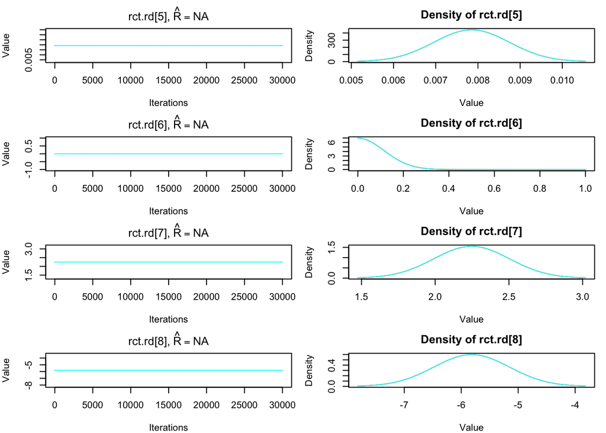

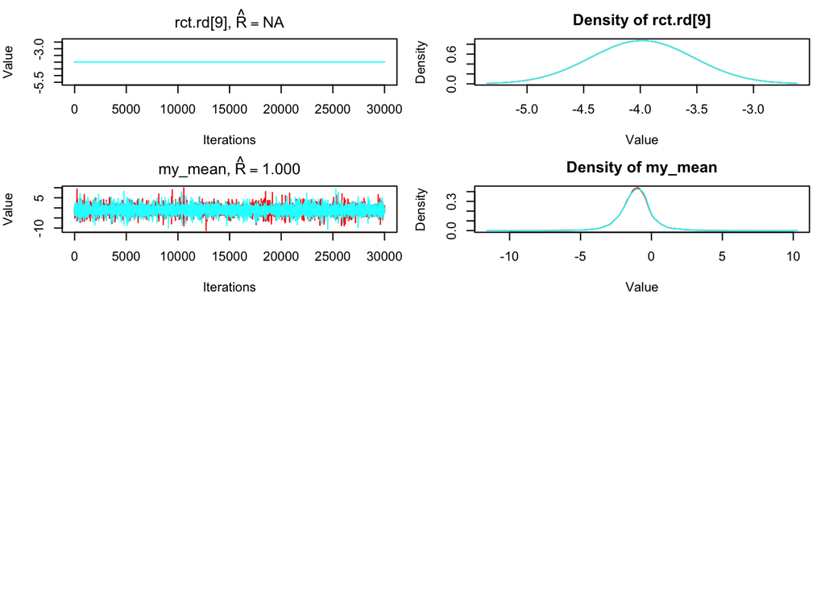

```r
plot(results, parameters=c("rct.rd", "my_mean"))
```

# Exercises

## `breast_screening`

This is the code for exercise 11.5 (p. 248)

Breast Screening - 3-level Hierarchical Model for Generalised Evidence Synthesis

Following Prevost et al Stat Med 2000;19 & Spiegelhalter et al (2003) Example 8.5

The WinBUGS code gave this error when I tried to run it in JAGS:

```
Error in rjags::jags.model(file = model.file, data = data, inits = inits,  :
  RUNTIME ERROR:
Compilation error on line 7.
```

Here is a copy of the WinBUGS version:

```
model {
  for (j in 1:Nstud) {
    logRR[j] <- log(RR[j])
    P[j]  <- 1/(SE[j]*SE[j])
    # Likelihood for within-type model
    logRR[j] ~ dnorm(delta[j],P[j])
    delta[j] ~ dnorm(phi[Type[j]],prec.stud[Type[j]])
  }

  # Likelihood for between-type model
  for (i in 1:Ntype) {
    phi[i] ~ dnorm(d,prec)
    prec.stud[i] <- 1/psi.sq[i]
    psi.sq[i] <- psi[i]*psi[i]
    psi[i] ~ dnorm(0,8)I(0,)

    # Prior for psi is derived on basis that individual study effect is unlikely to
    # deviate from type effect by more than 4 times or less than 1/4.
    # Therefore, upper 95% limit for psi = log(16)/(2*1.96) = 0.71.
    # Half-Normal(0,0.35^2) prior distribution has this property.

  }

  # Priors

  d ~ dnorm(0,0.1)

  # Prior for d is derived on the basis that the overall effect is unlikely to
  # to exceed 500 in favour of either screening or control.
  # Therefore, prior SD = log(500)/1.96 = 3.17 & precision = 1/(3.17^2) = 0.1.

  prec <- 1/tau.sq
  tau.sq <- tau*tau
  tau ~ dnorm(0,30)I(0,)

  # Prior for tau is derived on the basis that an specific type effect is unlikely
  # to deviate from the overall pooled effect (d) by more than 2 or less than 1/2.
  # Therefore, upper 95%  limit for tau = log(2)/(2*1.96) = 0.018.
  # Half-Normal(0,0.18^2) prior distribution has this property.


  # Transformation to Relative Risk scale
  for (i in 1:Ntype) {
    RR.type[i] <- exp(phi[i])
  }
  RR.ov <- exp(d)
}
```

To run it in JAGS, I moved the offending lines to a data block:

```r
# Model

model_code <- "

data {
  for (j in 1:Nstud) {
    logRR[j] <- log(RR[j])
  }
}

model {
  for (j in 1:Nstud) {
    # logRR[j] <- log(RR[j])  # !!! moved to data block
    P[j]  <- 1/(SE[j]*SE[j])
    # Likelihood for within-type model
    logRR[j] ~ dnorm(delta[j],P[j])
    delta[j] ~ dnorm(phi[Type[j]],prec.stud[Type[j]])
  }

  # Likelihood for between-type model
  for (i in 1:Ntype) {
    phi[i] ~ dnorm(d,prec)
    prec.stud[i] <- 1/psi.sq[i]
    psi.sq[i] <- psi[i]*psi[i]
    psi[i] ~ dnorm(0,8)I(0,)

    # Prior for psi is derived on basis that individual study effect is unlikely to
    # deviate from type effect by more than 4 times or less than 1/4.
    # Therefore, upper 95% limit for psi = log(16)/(2*1.96) = 0.71.
    # Half-Normal(0,0.35^2) prior distribution has this property.

  }

  # Priors

  d ~ dnorm(0,0.1)

  # Prior for d is derived on the basis that the overall effect is unlikely to
  # to exceed 500 in favour of either screening or control.
  # Therefore, prior SD = log(500)/1.96 = 3.17 & precision = 1/(3.17^2) = 0.1.

  prec <- 1/tau.sq
  tau.sq <- tau*tau
  tau ~ dnorm(0,30)I(0,)

  # Prior for tau is derived on the basis that an specific type effect is unlikely
  # to deviate from the overall pooled effect (d) by more than 2 or less than 1/2.
  # Therefore, upper 95%  limit for tau = log(2)/(2*1.96) = 0.018.
  # Half-Normal(0,0.18^2) prior distribution has this property.


  # Transformation to Relative Risk scale
  for (i in 1:Ntype) {
    RR.type[i] <- exp(phi[i])
  }
  RR.ov <- exp(d)
}
" %>% textConnection


# Data

data <- list(
  RR=c(0.70,0.66,0.79,0.80,0.64,0.80,0.80,0.26,0.30,0.24),
  SE=c(0.17,0.11,0.23,0.19,0.27,0.11,0.045,0.48,0.43,0.30),
  Type=c(1,1,1,1,1,2,2,2,2,2), # (type: 1=RCTs, 2=Obs)
  Nstud=10,
  Ntype=2
)

# Starting/initial values: same as random effects model without sd
initial_values <- list(
  list(
    delta=c(0,0,0,0,0,0,0,0,0,0),
    phi=c(0,0),
    d=0,
    tau=1,
    psi=c(1,1)
  )
)


parameters_to_save <- c("RR.ov", "RR.type", "d", "phi", "psi", "tau")


results <- jags(data = data,
            inits = initial_values,
            parameters.to.save = parameters_to_save,
            model.file = model_code,
            n.chains = length(initial_values),
            n.adapt = 100,
            n.iter = 50000,
            n.burnin = 20000,
            n.thin = 2)
```

```
##
## Processing function input.......
##
## Done.
##
## Compiling data graph
##    Initializing
##    Reading data back into data table
##
##
## Adaptive phase, 100 iterations x 1 chains
## If no progress bar appears JAGS has decided not to adapt
##
##
##  Burn-in phase, 20000 iterations x 1 chains
##
##
## Sampling from joint posterior, 30000 iterations x 1 chains
##
##
## Calculating statistics.......
##
## Done.
```

```r
summary(results)
```

```
##                  mean         sd          2.5%         25%         50%
## RR.ov       0.6483698 0.10697756   0.443207733  0.58614107  0.64613699
## RR.type[1]  0.6832142 0.06612247   0.561526730  0.64021585  0.68074629
## RR.type[2]  0.6086626 0.10413216   0.397991569  0.54115920  0.61398029
## d          -0.4469760 0.16701076  -0.813716699 -0.53419479 -0.43674374
## phi[1]     -0.3856424 0.09718034  -0.577095902 -0.44594989 -0.38456560
## phi[2]     -0.5119549 0.17929339  -0.921324474 -0.61404178 -0.48779246
## psi[1]      0.1083638 0.09538507   0.004470576  0.03834146  0.08299246
## psi[2]      0.4631489 0.16571863   0.185263168  0.34519558  0.44527997
## tau         0.1443047 0.10675417   0.005097145  0.05899234  0.12489434
## deviance   -5.1062297 4.59792699 -11.732143164 -8.46887337 -5.89950312
##                   75%      97.5% Rhat n.eff overlap0         f
## RR.ov       0.7067160  0.8718181   NA     1        0 1.0000000
## RR.type[1]  0.7247140  0.8185873   NA     1        0 1.0000000
## RR.type[2]  0.6757611  0.8096791   NA     1        0 1.0000000
## d          -0.3471264 -0.1371745   NA     1        0 0.9934667
## phi[1]     -0.3219782 -0.2001753   NA     1        0 0.9995333
## phi[2]     -0.3919157 -0.2111173   NA     1        0 0.9990000
## psi[1]      0.1510058  0.3617894   NA     1        0 1.0000000
## psi[2]      0.5649093  0.8344263   NA     1        0 1.0000000
## tau         0.2070257  0.3953262   NA     1        0 1.0000000
## deviance   -2.5804814  5.7248739   NA     1        1 0.8671333
```

```
Results from WinBUGS
    node     mean    sd  MC error   2.5%    median  97.5%   start   sample
    RR.ov   0.6518  0.1066  0.002882    0.4429  0.6503  0.8739  20001   10000
    RR.type[1]  0.6847  0.06534 0.002545    0.5622  0.682   0.8209  20001   10000
    RR.type[2]  0.6142  0.1066  0.003044    0.4014  0.6182  0.8172  20001   10000
    d   -0.4416 0.1667  0.004506    -0.8145 -0.4303 -0.1348 20001   10000
    phi[1]  -0.3834 0.09619 0.003775    -0.5759 -0.3827 -0.1974 20001   10000
    phi[2]  -0.5033 0.1814  0.00515 -0.9128 -0.4809 -0.2019 20001   10000
    psi[1]  0.1047  0.09434 0.003594    0.002431    0.07846 0.3512  20001   10000
    psi[2]  0.4653  0.1672  0.003304    0.1885  0.4476  0.8519  20001   10000
    tau 0.14    0.1053  0.002884    0.005694    0.1203  0.3903  20001   10000
```